# Shruthi_AIML_ML_Project_2_Personal_Loan_Campaign (1)

## Problem Statement

### Context

AllLife Bank is a US bank that has a growing customer base. The majority of these customers are liability customers (depositors) with varying sizes of deposits. The number of customers who are also borrowers (asset customers) is quite small, and the bank is interested in expanding this base rapidly to bring in more loan business and in the process, earn more through the interest on loans. In particular, the management wants to explore ways of converting its liability customers to personal loan customers (while retaining them as depositors).

A campaign that the bank ran last year for liability customers showed a healthy conversion rate of over 9% success. This has encouraged the retail marketing department to devise campaigns with better target marketing to increase the success ratio.

You as a Data scientist at AllLife bank have to build a model that will help the marketing department to identify the potential customers who have a higher probability of purchasing the loan.

### Objective

To predict whether a liability customer will buy personal loans, to understand which customer attributes are most significant in driving purchases, and identify which segment of customers to target more.

### Data Dictionary

- `ID`: Customer ID
- `Age`: Customer’s age in completed years
- `Experience`: #years of professional experience
- `Income`: Annual income of the customer (in thousand dollars)
- `ZIP Code`: Home Address ZIP code.
- `Family`: the Family size of the customer
- `CCAvg`: Average spending on credit cards per month (in thousand dollars)
- `Education`: Education Level. 1: Undergrad; 2: Graduate;3: Advanced/Professional
- `Mortgage`: Value of house mortgage if any. (in thousand dollars)
- `Personal_Loan`: Did this customer accept the personal loan offered in the last campaign? (0: No, 1: Yes)
- `Securities_Account`: Does the customer have securities account with the bank? (0: No, 1: Yes)
- `CD_Account`: Does the customer have a certificate of deposit (CD) account with the bank? (0: No, 1: Yes)
- `Online`: Do customers use internet banking facilities? (0: No, 1: Yes)
- `CreditCard`: Does the customer use a credit card issued by any other Bank (excluding All life Bank)? (0: No, 1: Yes)

## **Please read the instructions carefully before starting the project.**

This is a commented Jupyter IPython Notebook file in which all the instructions and tasks to be performed are mentioned.

- Blanks '**___**' are provided in the notebook that needs to be filled with an appropriate code to get the correct result. With every '**___**' blank, there is a comment that briefly describes what needs to be filled in the blank space.
- Identify the task to be performed correctly, and only then proceed to write the required code.
- Fill the code wherever asked by the commented lines like "# write your code here" or "# complete the code". Running incomplete code may throw error.
- Please run the codes in a sequential manner from the beginning to avoid any unnecessary errors.
- Add the results/observations (wherever mentioned) derived from the analysis in the presentation and submit the same.

## Importing necessary libraries

```python
# Installing the libraries with the specified version.
!pip install numpy==1.25.2 pandas==1.5.3 matplotlib==3.7.1 seaborn==0.13.1 scikit-learn==1.2.2 sklearn-pandas==2.2.0 -q --user
```

**Note**: *After running the above cell, kindly restart the notebook kernel and run all cells sequentially from the start again.*

```python
# Libraries to help with reading and manipulating data
import pandas as pd
import numpy as np

# libaries to help with data visualization
import matplotlib.pyplot as plt
import seaborn as sns

# Removes the limit for the number of displayed columns
pd.set_option("display.max_columns", None)
# Sets the limit for the number of displayed rows
pd.set_option("display.max_rows", 200)

# Library to split data
from sklearn.model_selection import train_test_split

# To build model for prediction
from sklearn.tree import DecisionTreeClassifier
from sklearn import tree

# To tune different models
from sklearn.model_selection import GridSearchCV

# To get diferent metric scores
from sklearn.metrics import (
    f1_score,
    accuracy_score,
    recall_score,
    precision_score,
    confusion_matrix,
    make_scorer,
)

import warnings
warnings.filterwarnings("ignore")
```

## Loading the dataset

```python
# uncomment the following lines if Google Colab is being used
from google.colab import drive
drive.mount('/content/drive')
```

```python
Loan = pd.read_csv('/content/drive/MyDrive/Colab Datafiles/Loan_Modelling.csv')  ##  Complete the code to read the data
```

```python
# copying data to another variable to avoid any changes to original data
data = Loan.copy()
```

## Data Overview

### View the first and last 5 rows of the dataset.

```python
data.head() ##  Complete the code to view top 5 rows of the data
```

|  | ID | Age | Experience | Income | ZIPCode | Family | CCAvg | Education | Mortgage | Personal_Loan | Securities_Account | CD_Account | Online | CreditCard |
| --- | --- | --- | --- | --- | --- | --- | --- | --- | --- | --- | --- | --- | --- | --- |
| 0 | 1 | 25 | 1 | 49 | 91107 | 4 | 1.6 | 1 | 0 | 0 | 1 | 0 | 0 | 0 |
| 1 | 2 | 45 | 19 | 34 | 90089 | 3 | 1.5 | 1 | 0 | 0 | 1 | 0 | 0 | 0 |
| 2 | 3 | 39 | 15 | 11 | 94720 | 1 | 1.0 | 1 | 0 | 0 | 0 | 0 | 0 | 0 |
| 3 | 4 | 35 | 9 | 100 | 94112 | 1 | 2.7 | 2 | 0 | 0 | 0 | 0 | 0 | 0 |
| 4 | 5 | 35 | 8 | 45 | 91330 | 4 | 1.0 | 2 | 0 | 0 | 0 | 0 | 0 | 1 |

```python
# Calculate the number of missing values per column
missing_values = data.isnull().sum()

# Calculate the percentage of missing values per column
missing_percent = (data.isnull().sum() / len(data)) * 100

# Print the number of missing values and their percentage for each column
print("Missing Values Per Column:")
print(missing_values[missing_values > 0])
print("\nPercentage of Missing Values Per Column:")
print(missing_percent[missing_percent > 0])
```

```
Missing Values Per Column:
Series([], dtype: int64)

Percentage of Missing Values Per Column:
Series([], dtype: float64)
```

```python
data.tail()  ##  Complete the code to view last 5 rows of the data
```

|  | ID | Age | Experience | Income | ZIPCode | Family | CCAvg | Education | Mortgage | Personal_Loan | Securities_Account | CD_Account | Online | CreditCard |
| --- | --- | --- | --- | --- | --- | --- | --- | --- | --- | --- | --- | --- | --- | --- |
| 4995 | 4996 | 29 | 3 | 40 | 92697 | 1 | 1.9 | 3 | 0 | 0 | 0 | 0 | 1 | 0 |
| 4996 | 4997 | 30 | 4 | 15 | 92037 | 4 | 0.4 | 1 | 85 | 0 | 0 | 0 | 1 | 0 |
| 4997 | 4998 | 63 | 39 | 24 | 93023 | 2 | 0.3 | 3 | 0 | 0 | 0 | 0 | 0 | 0 |
| 4998 | 4999 | 65 | 40 | 49 | 90034 | 3 | 0.5 | 2 | 0 | 0 | 0 | 0 | 1 | 0 |
| 4999 | 5000 | 28 | 4 | 83 | 92612 | 3 | 0.8 | 1 | 0 | 0 | 0 | 0 | 1 | 1 |

```python
print(data.columns)
```

```
Index(['ID', 'Age', 'Experience', 'Income', 'ZIPCode', 'Family', 'CCAvg',
       'Education', 'Mortgage', 'Personal_Loan', 'Securities_Account',
       'CD_Account', 'Online', 'CreditCard'],
      dtype='object')
```

```python
duplicate_rows = data.duplicated()
print("Number of duplicate rows:", duplicate_rows.sum())
duplicate_rows_specific = data.duplicated(subset=['ID',  'ZIPCode'])
print("Number of duplicate rows based on specific columns:", duplicate_rows_specific.sum())
print(data[duplicate_rows])
```

```
Number of duplicate rows: 0
Number of duplicate rows based on specific columns: 0
Empty DataFrame
Columns: [ID, Age, Experience, Income, ZIPCode, Family, CCAvg, Education, Mortgage, Personal_Loan, Securities_Account, CD_Account, Online, CreditCard]
Index: []
```

### Understand the shape of the dataset.

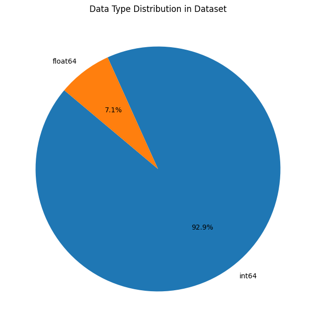

```python
import matplotlib.pyplot as plt

# Assuming 'data' is your DataFrame
# Count the number of columns of each data type
data_type_counts = data.dtypes.value_counts()

# Plot the distribution of data types as a pie chart
plt.figure(figsize=(8, 8))
plt.pie(data_type_counts, labels=data_type_counts.index, autopct='%1.1f%%', startangle=140)
plt.title('Data Type Distribution in Dataset')
plt.show()
```

```python
data.shape  ## Complete the code to get the shape of the data
```

```
(5000, 14)
```

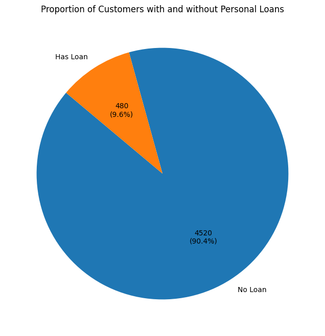

```python
# Count the instances of each category
loan_counts = data['Personal_Loan'].value_counts()

plt.figure(figsize=(8, 8))
plt.pie(loan_counts, labels=['No Loan', 'Has Loan'], autopct=lambda p: '{:.0f}\n({:.1f}%)'.format(p * sum(loan_counts) / 100, p), startangle=140)
plt.title('Proportion of Customers with and without Personal Loans')
plt.show()
```

### Check the data types of the columns for the dataset

```python
data.info()  ##  Complete the code to view the datatypes of the data
```

```
<class 'pandas.core.frame.DataFrame'>
RangeIndex: 5000 entries, 0 to 4999
Data columns (total 14 columns):
 #   Column              Non-Null Count  Dtype
---  ------              --------------  -----
 0   ID                  5000 non-null   int64
 1   Age                 5000 non-null   int64
 2   Experience          5000 non-null   int64
 3   Income              5000 non-null   int64
 4   ZIPCode             5000 non-null   int64
 5   Family              5000 non-null   int64
 6   CCAvg               5000 non-null   float64
 7   Education           5000 non-null   int64
 8   Mortgage            5000 non-null   int64
 9   Personal_Loan       5000 non-null   int64
 10  Securities_Account  5000 non-null   int64
 11  CD_Account          5000 non-null   int64
 12  Online              5000 non-null   int64
 13  CreditCard          5000 non-null   int64
dtypes: float64(1), int64(13)
memory usage: 547.0 KB
```

### Checking the Statistical Summary

```python
data.describe().T  ## Complete the code to print the statistical summary of the data
```

|  | count | mean | std | min | 25% | 50% | 75% | max |
| --- | --- | --- | --- | --- | --- | --- | --- | --- |
| ID | 5000.0 | 2500.500000 | 1443.520003 | 1.0 | 1250.75 | 2500.5 | 3750.25 | 5000.0 |
| Age | 5000.0 | 45.338400 | 11.463166 | 23.0 | 35.00 | 45.0 | 55.00 | 67.0 |
| Experience | 5000.0 | 20.104600 | 11.467954 | -3.0 | 10.00 | 20.0 | 30.00 | 43.0 |
| Income | 5000.0 | 73.774200 | 46.033729 | 8.0 | 39.00 | 64.0 | 98.00 | 224.0 |
| ZIPCode | 5000.0 | 93169.257000 | 1759.455086 | 90005.0 | 91911.00 | 93437.0 | 94608.00 | 96651.0 |
| Family | 5000.0 | 2.396400 | 1.147663 | 1.0 | 1.00 | 2.0 | 3.00 | 4.0 |
| CCAvg | 5000.0 | 1.937938 | 1.747659 | 0.0 | 0.70 | 1.5 | 2.50 | 10.0 |
| Education | 5000.0 | 1.881000 | 0.839869 | 1.0 | 1.00 | 2.0 | 3.00 | 3.0 |
| Mortgage | 5000.0 | 56.498800 | 101.713802 | 0.0 | 0.00 | 0.0 | 101.00 | 635.0 |
| Personal_Loan | 5000.0 | 0.096000 | 0.294621 | 0.0 | 0.00 | 0.0 | 0.00 | 1.0 |
| Securities_Account | 5000.0 | 0.104400 | 0.305809 | 0.0 | 0.00 | 0.0 | 0.00 | 1.0 |
| CD_Account | 5000.0 | 0.060400 | 0.238250 | 0.0 | 0.00 | 0.0 | 0.00 | 1.0 |
| Online | 5000.0 | 0.596800 | 0.490589 | 0.0 | 0.00 | 1.0 | 1.00 | 1.0 |
| CreditCard | 5000.0 | 0.294000 | 0.455637 | 0.0 | 0.00 | 0.0 | 1.00 | 1.0 |

### Observations from Data overview

The Experience attribute includes negative values, which seems incorrect and needs correction or explanation. Binary and categorical variables are already encoded, which simplifies the process of preparing data for modeling. The target variable for prediction is Personal Loan, indicating if a customer accepted a personal loan offer.

Next steps might include:

Addressing the negative values in the Experience column. Exploring the distribution of key attributes, especially how they relate to the target variable Personal Loan. Investigating correlations between variables to identify potential predictors for loan acceptance.

### Dropping columns

```python
data = data.drop(['ID'], axis=1)  ## Complete the code to drop a column from the dataframe
```

```python
data.head()
```

|  | Age | Experience | Income | ZIPCode | Family | CCAvg | Education | Mortgage | Personal_Loan | Securities_Account | CD_Account | Online | CreditCard |
| --- | --- | --- | --- | --- | --- | --- | --- | --- | --- | --- | --- | --- | --- |
| 0 | 25 | 1 | 49 | 91107 | 4 | 1.6 | 1 | 0 | 0 | 1 | 0 | 0 | 0 |
| 1 | 45 | 19 | 34 | 90089 | 3 | 1.5 | 1 | 0 | 0 | 1 | 0 | 0 | 0 |
| 2 | 39 | 15 | 11 | 94720 | 1 | 1.0 | 1 | 0 | 0 | 0 | 0 | 0 | 0 |
| 3 | 35 | 9 | 100 | 94112 | 1 | 2.7 | 2 | 0 | 0 | 0 | 0 | 0 | 0 |
| 4 | 35 | 8 | 45 | 91330 | 4 | 1.0 | 2 | 0 | 0 | 0 | 0 | 0 | 1 |

## Data Preprocessing

### Checking for Anomalous Values

```python
# Displaying rows where the Experience is negative in the 'data' dataframe
negative_experience_rows = data[data['Experience'] < 0]

negative_experience_rows.head(), negative_experience_rows.shape
```

[output not shown]

### Observations

There are 52 rows in the dataset where the "Experience" column has negative values.

```python
data["Experience"].unique()
```

```
array([ 1, 19, 15,  9,  8, 13, 27, 24, 10, 39,  5, 23, 32, 41, 30, 14, 18,
       21, 28, 31, 11, 16, 20, 35,  6, 25,  7, 12, 26, 37, 17,  2, 36, 29,
        3, 22, -1, 34,  0, 38, 40, 33,  4, -2, 42, -3, 43])
```

```python
# checking for experience <0
data[data["Experience"] < 0]["Experience"].unique()
```

```
array([-1, -2, -3])
```

```python
# Correcting the experience values
data["Experience"].replace(-1, 1, inplace=True)
data["Experience"].replace(-2, 2, inplace=True)
data["Experience"].replace(-3, 3, inplace=True)
```

```python
data["Education"].unique()
```

```
array([1, 2, 3])
```

### Feature Engineering

```python
# checking the number of uniques in the zip code
data["ZIPCode"].nunique()
```

```
467
```

```python
data["ZIPCode"] = data["ZIPCode"].astype(str)
print(
    "Number of unique values if we take first two digits of ZIPCode: ",
    data["ZIPCode"].str[0:2].nunique(),
)
data["ZIPCode"] = data["ZIPCode"].str[0:2]

data["ZIPCode"] = data["ZIPCode"].astype("category")
```

```
Number of unique values if we take first two digits of ZIPCode:  7
```

```python
## Converting the data type of categorical features to 'category'
cat_cols = [
    "Education",
    "Personal_Loan",
    "Securities_Account",
    "CD_Account",
    "Online",
    "CreditCard",
    "ZIPCode",
]
data[cat_cols] = data[cat_cols].astype("category")
```

```python
data.info()
```

```
<class 'pandas.core.frame.DataFrame'>
RangeIndex: 5000 entries, 0 to 4999
Data columns (total 13 columns):
 #   Column              Non-Null Count  Dtype
---  ------              --------------  -----
 0   Age                 5000 non-null   int64
 1   Experience          5000 non-null   int64
 2   Income              5000 non-null   int64
 3   ZIPCode             5000 non-null   category
 4   Family              5000 non-null   int64
 5   CCAvg               5000 non-null   float64
 6   Education           5000 non-null   category
 7   Mortgage            5000 non-null   int64
 8   Personal_Loan       5000 non-null   category
 9   Securities_Account  5000 non-null   category
 10  CD_Account          5000 non-null   category
 11  Online              5000 non-null   category
 12  CreditCard          5000 non-null   category
dtypes: category(7), float64(1), int64(5)
memory usage: 269.8 KB
```

## Exploratory Data Analysis (EDA)

### Univariate Analysis

```python
def histogram_boxplot(data, feature, figsize=(12, 7), kde=False, bins=None):
    """
    Boxplot and histogram combined

    data: dataframe
    feature: dataframe column
    figsize: size of figure (default (12,7))
    kde: whether to show the density curve (default False)
    bins: number of bins for histogram (default None)
    """
    f2, (ax_box2, ax_hist2) = plt.subplots(
        nrows=2,  # Number of rows of the subplot grid= 2
        sharex=True,  # x-axis will be shared among all subplots
        gridspec_kw={"height_ratios": (0.25, 0.75)},
        figsize=figsize,
    )  # creating the 2 subplots
    sns.boxplot(
        data=data, x=feature, ax=ax_box2, showmeans=True, color="violet"
    )  # boxplot will be created and a star will indicate the mean value of the column
    sns.histplot(
        data=data, x=feature, kde=kde, ax=ax_hist2, bins=bins, palette="winter"
    ) if bins else sns.histplot(
        data=data, x=feature, kde=kde, ax=ax_hist2
    )  # For histogram
    ax_hist2.axvline(
        data[feature].mean(), color="green", linestyle="--"
    )  # Add mean to the histogram
    ax_hist2.axvline(
        data[feature].median(), color="black", linestyle="-"
    )  # Add median to the histogram
```

```python
# function to create labeled barplots


def labeled_barplot(data, feature, perc=False, n=None):
    """
    Barplot with percentage at the top

    data: dataframe
    feature: dataframe column
    perc: whether to display percentages instead of count (default is False)
    n: displays the top n category levels (default is None, i.e., display all levels)
    """

    total = len(data[feature])  # length of the column
    count = data[feature].nunique()
    if n is None:
        plt.figure(figsize=(count + 1, 5))
    else:
        plt.figure(figsize=(n + 1, 5))

    plt.xticks(rotation=90, fontsize=15)
    ax = sns.countplot(
        data=data,
        x=feature,
        palette="Paired",
        order=data[feature].value_counts().index[:n].sort_values(),
    )

    for p in ax.patches:
        if perc == True:
            label = "{:.1f}%".format(
                100 * p.get_height() / total
            )  # percentage of each class of the category
        else:
            label = p.get_height()  # count of each level of the category

        x = p.get_x() + p.get_width() / 2  # width of the plot
        y = p.get_height()  # height of the plot

        ax.annotate(
            label,
            (x, y),
            ha="center",
            va="center",
            size=12,
            xytext=(0, 5),
            textcoords="offset points",
        )  # annotate the percentage

    plt.show()  # show the plot
```

#### Observations on Age

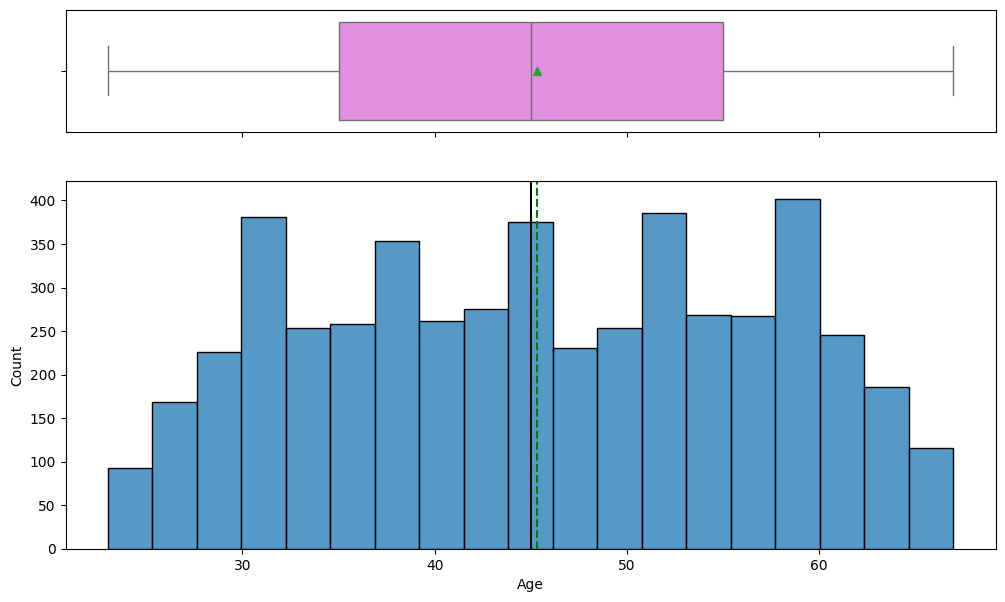

```python
histogram_boxplot(data, "Age")
```

### Observations on Age

Based on the histogram and boxplot for the "Age" variable, here are a few observations:

Distribution Shape: The histogram indicates that the age distribution is fairly uniform with a slight concentration around the median age. There doesn't appear to be any significant skewness to the left or right, suggesting a relatively even distribution of customers across different ages.

Variability: The boxplot's interquartile range (the width of the box) suggests that the middle 50% of customers' ages are spread across a decent range, likely around 20 years or so, indicating a good mix of ages among the bank's customers.

Outliers: There do not appear to be any outliers on either end of the age spectrum, as there are no points plotted beyond the "whiskers" of the boxplot.

Symmetry: The symmetry of the boxplot, along with the relatively flat histogram, suggests that the age data is quite symmetric around the median.

Potential Issues: There do not appear to be any immediate issues with the "Age" data that would require cleanup, such as outliers or missing values.

This well-distributed age data is good for analysis, as it indicates a diverse customer base in terms of age, which can be beneficial when trying to generalize findings or build predictive models.

#### Observations on Experience

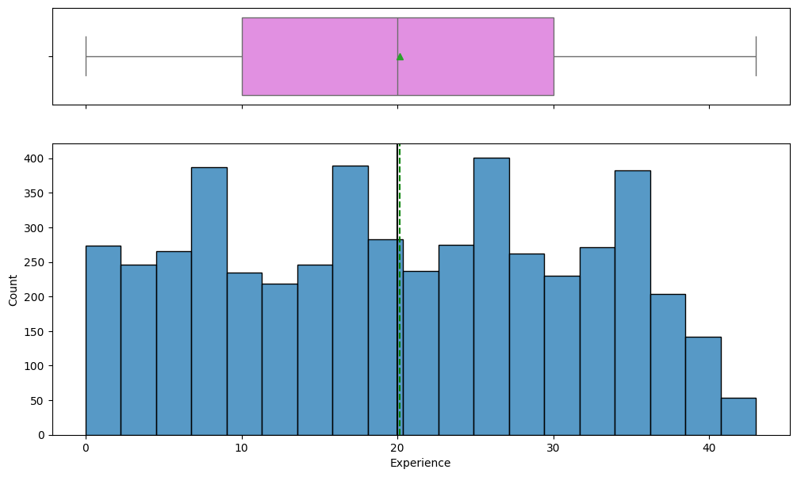

```python
histogram_boxplot(data,'Experience') ## Complete the code to create histogram_boxplot for experience
```

### Observations on Experiance

Observations for the "Experience" variable based on the histogram and boxplot are as follows:

Distribution: The distribution of experience years among customers is somewhat uniform but slightly right-skewed, as indicated by the histogram. Most customers have experience ranging roughly from 8 to 30 years.

Spread: The interquartile range of the boxplot, which represents the middle 50% of the data, appears to span a broad range of the experience spectrum, suggesting that the bank's customers have a varied amount of professional experience.

Outliers: There do not seem to be any outliers in the data, as there are no data points beyond the whiskers of the boxplot. This indicates that all customers' experience levels fall within a reasonable range.

Symmetry: The boxplot shows a fairly symmetric distribution about the median, with the mean (shown by the green diamond) also near the median, which suggests that there are no extreme values pulling the distribution to one end.

Potential Data Issues: There is no evidence from this plot of the negative experience values that were mentioned earlier in the data. This suggests that those values have either been corrected, as per your previous action, or they are too few to significantly alter the appearance of the distribution in this plot.

Overall, the "Experience" data appears to be well-distributed across the customer base, with most customers having a moderate level of professional experience, and no apparent problematic data quality issues.

#### Observations on Income

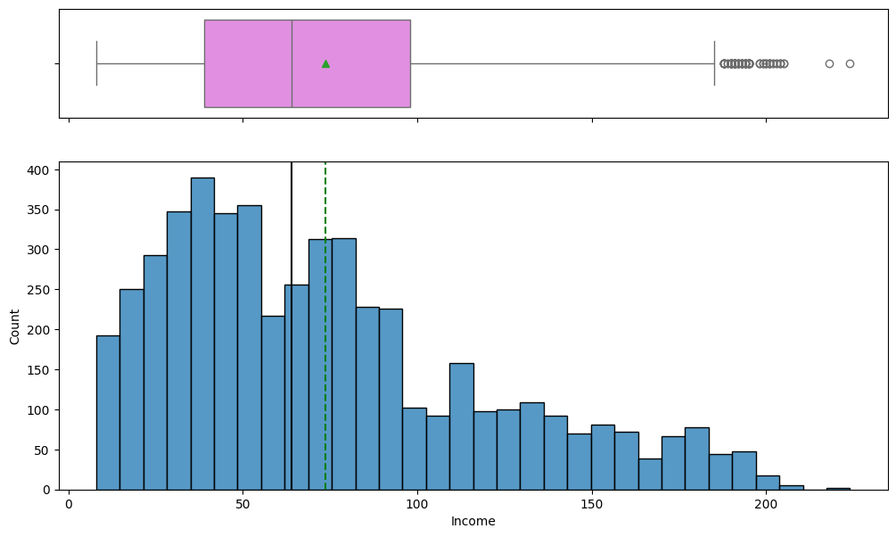

```python
histogram_boxplot(data,'Income')  ## Complete the code to create histogram_boxplot for Income
```

### Observations on Income

From the provided histogram and boxplot for the "Income" variable, here are the observations:

Distribution: The histogram shows a right-skewed distribution for income, indicating that a larger number of customers have lower incomes, and fewer customers have higher incomes.

Central Tendency: The median income, marked by the line in the middle of the box in the boxplot, is lower than the mean income, which is indicated by the green diamond. This is typical for a right-skewed distribution.

Spread and Variability: The interquartile range (the width of the box in the boxplot) seems to be quite wide, indicating considerable variability in income among the customers. The tails of the distribution extend further to the right, showing that there are customers with very high incomes, although they are fewer in number.

Outliers: There are several outliers on the higher end of the income scale, as indicated by the points beyond the upper whisker of the boxplot. These outliers suggest that there are some customers with exceptionally high incomes compared to the rest of the population.

High-Income Customers: The boxplot shows that the top quartile of customers have a relatively high income, which could be of particular interest for marketing strategies, especially for products and services aimed at higher-income individuals.

Income Distribution Insights: The skewness towards lower income suggests that the bank has a large number of customers in the lower to middle-income brackets, which might be the target for different types of loan products compared to those customers identified as outliers.

Overall, the distribution of income among the bank's customers highlights the diversity in economic backgrounds, which is crucial for tailoring personalized banking products and services. The presence of high-income outliers could represent opportunities for upselling premium services or products.

#### Observations on CCAvg

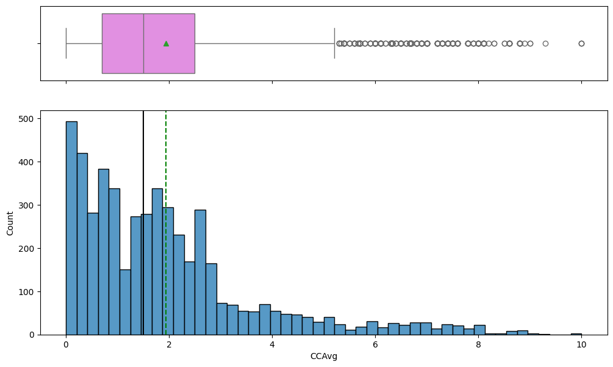

```python
histogram_boxplot(data,'CCAvg')  ## Complete the code to create histogram_boxplot for CCAvg
```

### Observations on CCAvg

Based on the histogram and boxplot provided for the CCAvg (average spending on credit cards per month in thousand dollars), here are the observations:

Right-Skewed Distribution: The histogram shows that the distribution of CCAvg is right-skewed. Most customers have lower average credit card spending, with a tail extending towards higher spend levels.

Central Tendency: The median average spending (visible as the line within the box in the boxplot) is less than the mean (indicated by the green triangle), which is typical for a right-skewed distribution. This suggests that while some customers spend quite a bit on their credit cards, the majority spend less.

Outliers: There is a significant number of outliers on the higher end as shown in the boxplot. These are customers who spend much more on their credit cards than typical customers.

Spread and Variability: The interquartile range (IQR) seems relatively tight, but because of the long right tail, there is a substantial spread in the upper quartile. This indicates that while half of the customers have a fairly consistent credit card spending, the other half can vary widely.

High Credit Card Spenders: The outliers suggest that there is a smaller segment of the customer base that uses their credit cards very heavily compared to the average customer. This group could be of particular interest for marketing campaigns aimed at high spenders or premium credit card offerings.

Analytical Considerations: The presence of many outliers and a skewed distribution may require transformation for certain types of predictive modeling or may inform the bank about the need to segment customers based on their spending patterns.

#### Observations on Mortgage

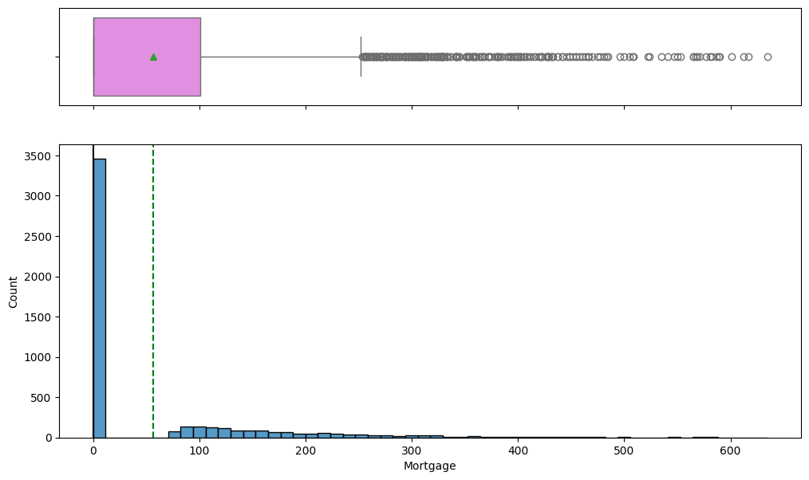

```python
histogram_boxplot(data,'Mortgage')  ## Complete the code to create histogram_boxplot for Mortgage
```

```python
# Customers with a mortgage will have a 'Mortgage' value greater than 0
have_mortgage_count = (data['Mortgage'] > 0).sum()

# Customers without a mortgage will have a 'Mortgage' value equal to 0
no_mortgage_count = (data['Mortgage'] == 0).sum()
print('Customers with Mortgage =',have_mortgage_count)
print('Customers without Mortgage = ',no_mortgage_count)
```

```
Customers with Mortgage = 1538
Customers without Mortgage =  3462
```

### Observations on Mortgage

Observations from the histogram and boxplot for the "Mortgage" variable can be noted as follows:

High Concentration of Zero Values: A significant portion of customers appear to have zero or very low mortgage values, as indicated by the tall bar at the beginning of the histogram.

Right-Skewed Distribution: Similar to the CCAvg variable, the distribution for Mortgage is also right-skewed. This skewness is quite pronounced, with the majority of the data clustered near zero.

Central Tendency: The median mortgage value is low, as shown by the line in the middle of the box in the boxplot, and it is quite close to zero, which is consistent with the large number of customers having no or low mortgage values.

Outliers: There are many outliers on the higher end, indicating that a smaller number of customers have very high mortgage values. These are beyond the upper whisker of the boxplot.

Spread and Variability: The interquartile range is small, suggesting that for those customers who do have a mortgage, the amounts are not highly varied. However, the long tail and outliers suggest that while mortgages are uncommon among the majority, they can reach very high values for a few customers.

Low Mortgage Customers: The vast majority of customers either do not have a mortgage or have a very small mortgage value on their house, which could be indicative of the customer base's financial behaviors or the bank's mortgage product uptake.

Analytical Considerations: Given the large number of zero values, any predictive models would need to handle this distribution appropriately, possibly treating the presence of a mortgage as a separate binary feature and the amount as a conditional feature only for those with a mortgage.

Financial Product Opportunities: The data suggests there could be an opportunity to market mortgage products to customers who currently do not have a mortgage, considering the large proportion of such customers.

The prevalence of zero or low mortgage values might indicate that mortgages are not as commonly held among the customers of the bank, or that the dataset includes a significant number of younger or less financially leveraged individuals.

#### Observations on Family

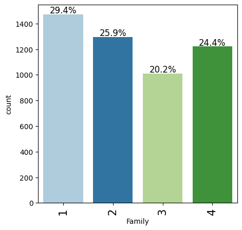

```python
labeled_barplot(data, "Family", perc=True)
```

#### Observations on Education

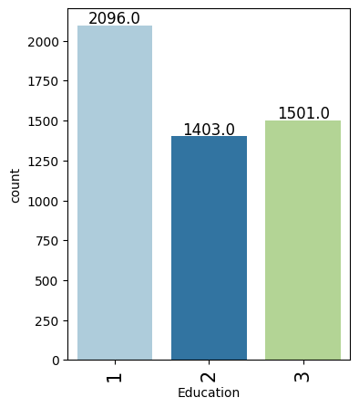

```python
labeled_barplot(data,'Education')   ## Complete the code to create labeled_barplot for Education
```

#### Observations on Securities_Account

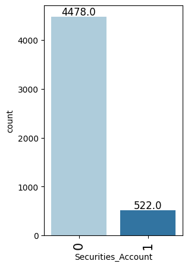

```python
labeled_barplot(data,'Securities_Account')   ## Complete the code to create labeled_barplot for Securities_Account
```

#### Observations on CD_Account

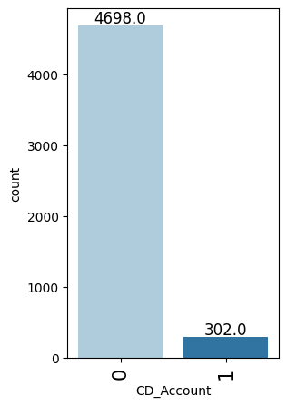

```python
labeled_barplot(data,'CD_Account')   ## Complete the code to create labeled_barplot for CD_Account
```

#### Observations on Online

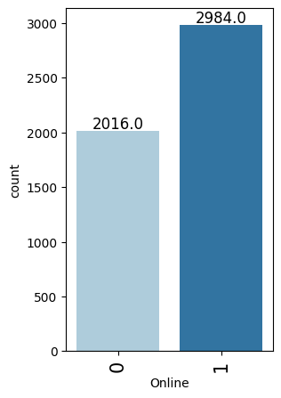

```python
labeled_barplot(data,'Online')   ## Complete the code to create labeled_barplot for Online
```

#### Observation on CreditCard

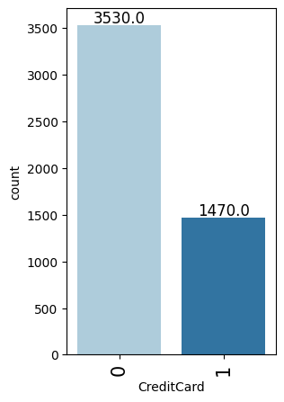

```python
labeled_barplot(data,'CreditCard')   ## Complete the code to create labeled_barplot for CreditCard
```

#### Observation on ZIPCode

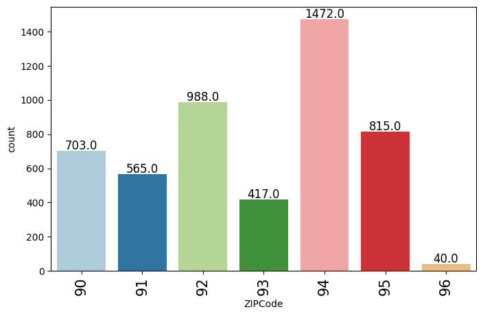

```python
labeled_barplot(data,'ZIPCode')   ## Complete the code to create labeled_barplot for ZIPCode
```

### Bivariate Analysis

```python
def stacked_barplot(data, predictor, target):
    """
    Print the category counts and plot a stacked bar chart

    data: dataframe
    predictor: independent variable
    target: target variable
    """
    count = data[predictor].nunique()
    sorter = data[target].value_counts().index[-1]
    tab1 = pd.crosstab(data[predictor], data[target], margins=True).sort_values(
        by=sorter, ascending=False
    )
    print(tab1)
    print("-" * 120)
    tab = pd.crosstab(data[predictor], data[target], normalize="index").sort_values(
        by=sorter, ascending=False
    )
    tab.plot(kind="bar", stacked=True, figsize=(count + 5, 5))
    plt.legend(
        loc="lower left", frameon=False,
    )
    plt.legend(loc="upper left", bbox_to_anchor=(1, 1))
    plt.show()
```

```python
### function to plot distributions wrt target


def distribution_plot_wrt_target(data, predictor, target):

    fig, axs = plt.subplots(2, 2, figsize=(12, 10))

    target_uniq = data[target].unique()

    axs[0, 0].set_title("Distribution of target for target=" + str(target_uniq[0]))
    sns.histplot(
        data=data[data[target] == target_uniq[0]],
        x=predictor,
        kde=True,
        ax=axs[0, 0],
        color="teal",
        stat="density",
    )

    axs[0, 1].set_title("Distribution of target for target=" + str(target_uniq[1]))
    sns.histplot(
        data=data[data[target] == target_uniq[1]],
        x=predictor,
        kde=True,
        ax=axs[0, 1],
        color="orange",
        stat="density",
    )

    axs[1, 0].set_title("Boxplot w.r.t target")
    sns.boxplot(data=data, x=target, y=predictor, ax=axs[1, 0], palette="gist_rainbow")

    axs[1, 1].set_title("Boxplot (without outliers) w.r.t target")
    sns.boxplot(
        data=data,
        x=target,
        y=predictor,
        ax=axs[1, 1],
        showfliers=False,
        palette="gist_rainbow",
    )

    plt.tight_layout()
    plt.show()
```

#### Correlation check

[figure not shown]

```python
plt.figure(figsize=(15, 7))
sns.heatmap(data.corr(), annot=True, vmin=-1, vmax=1, fmt=".2f", cmap="Spectral") # Complete the code to get the heatmap of the data
plt.show()
```

### Observations from the heat map

From the provided correlation heatmap, here are some observations:

Age and Experience: There's a very high positive correlation (~0.99) between Age and Experience, which is expected as they are inherently related; the older you are, the more professional experience you typically have.

Income and CCAvg: There's a significant positive correlation (0.65) between Income and CCAvg, suggesting that customers with higher incomes tend to spend more on credit cards.

No Strong Negative Correlations: There don't appear to be any strong negative correlations between variables, which suggests that there aren't variables that move inversely with one another in a significant way within this dataset.

It's important to note that while correlation can indicate a potential relationship between two variables, it does not imply causation. Further analysis would be required to understand the nature and causality of these relationships.

#### Let's check how a customer's interest in purchasing a loan varies with their education

```
Education         1     2     3   All
Personal_Loan
All            2096  1403  1501  5000
0              2003  1221  1296  4520
1                93   182   205   480
------------------------------------------------------------------------------------------------------------------------
```

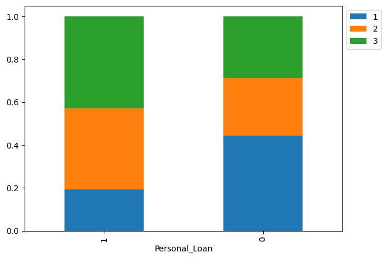

```python
stacked_barplot(data, "Personal_Loan", "Education")
```

### Observations Education Vs Personal Loan

Proportions Across Loan Status: The plot shows the distribution of education levels among those who have (1) and have not (0) taken a personal loan. Each education level is represented in both groups.

Comparison of Education Levels:

For both customers with and without a personal loan, all three education levels are present. There seems to be a relatively higher proportion of customers with an education level of '1' (Undergrad) who have not taken a personal loan (0) compared to those who have (1). Conversely, the proportion of customers with higher education (levels '2' and '3') is larger among those who have taken a personal loan (1). Indication of Influence:

The different distributions suggest that education level may have an influence on whether a customer takes a personal loan. Specifically, it appears that customers with a Graduate or an Advanced/Professional degree are more likely to take a personal loan than those with only an undergraduate degree. Targeting Based on Education:

This information could be useful for the bank's marketing strategies. It might suggest that targeting higher education levels could be more fruitful for converting customers to personal loan products. This visual seems to align with the idea that customers' educational attainment could play a role in their financial behavior, specifically their propensity to take a personal loan. However, statistical tests would still be necessary to confirm any significant association.

#### Personal_Loan vs Family

```
Family            1     2     3     4   All
Personal_Loan
All            1472  1296  1010  1222  5000
0              1365  1190   877  1088  4520
1               107   106   133   134   480
------------------------------------------------------------------------------------------------------------------------
```

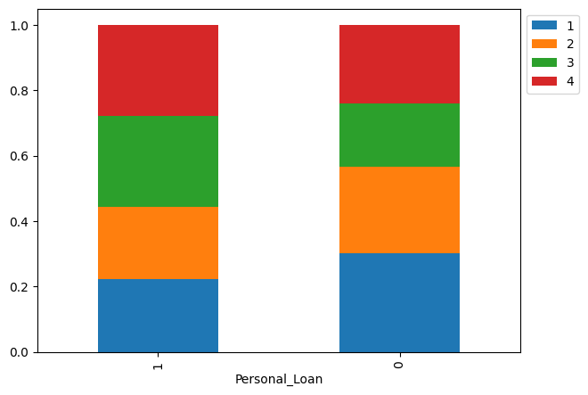

```python
stacked_barplot(data,'Personal_Loan','Family')  ## Complete the code to plot stacked barplot for Personal Loan and Family
```

### Observations from the plot Personal_Loan Vs Family

From the stacked bar plot showing the relationship between the number of family members (presumably represented by '1', '2', '3', '4') and the status of taking a personal loan ('0' for no loan, '1' for loan taken), here are the observations:

Family Size Distribution: Both categories of personal loan status ('0' and '1') contain customers from all family sizes. This suggests that family size alone is not a determining factor for taking out a personal loan.

Data Analysis Considerations: To gain more insights, a more detailed statistical analysis might be required to uncover any subtle effects of family size on personal loan uptake. This analysis could include testing for statistical significance or controlling for other variables in a multivariate context.

#### Personal_Loan vs Securities_Account

```
Securities_Account     0    1   All
Personal_Loan
All                 4478  522  5000
0                   4058  462  4520
1                    420   60   480
------------------------------------------------------------------------------------------------------------------------
```

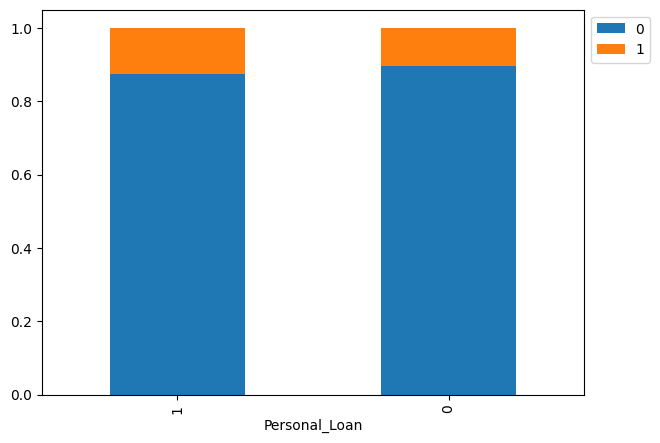

```python
stacked_barplot(data,'Personal_Loan','Securities_Account') ## Complete the code to plot stacked barplot for Personal Loan and Securities_Account
```

### Observations Personal Loan Vs Securities Account

The stacked bar plot appears to compare the presence of a securities account ('1' for yes, '0' for no) with whether customers have taken a personal loan ('1' for loan taken, '0' for no loan).

Here are the observations based on the plot:

Securities Account Holders: There is a visible proportion of customers with securities accounts in both the groups who have and have not taken a personal loan.

No Loan vs. Loan Taken: The relative size of the segments for securities account holders appears similar in both groups. This suggests that having a securities account may not be a strong predictor of whether a customer will take a personal loan.

Dominance of Non-Holders: The majority of customers in both categories do not have a securities account. This is visible from the larger blue segment in both bars.

Implications for Bank Services: The data may imply that whether or not someone has a securities account does not have a strong relationship with the decision to take a personal loan. However, it also indicates that a securities account is not a common product among the customers, or it is independent of their need for a loan.

Data Analysis Considerations: Just like with family size, to draw more definitive conclusions about the relationship between having a securities account and personal loan uptake, it would be beneficial to perform additional statistical analysis, potentially examining the interaction with other variables or conducting predictive modeling.

Comparison with Overall Proportions: To understand the significance of these observations, it would be helpful to compare these proportions to the overall proportion of customers who have securities accounts in the entire dataset.

The visualization shows that personal loan uptake seems to occur regardless of whether customers have a securities account, which could suggest that loan marketing efforts might be similarly targeted at customers regardless of this particular account status.

#### Personal_Loan vs CD_Account

```
CD_Account        0    1   All
Personal_Loan
All            4698  302  5000
0              4358  162  4520
1               340  140   480
------------------------------------------------------------------------------------------------------------------------
```

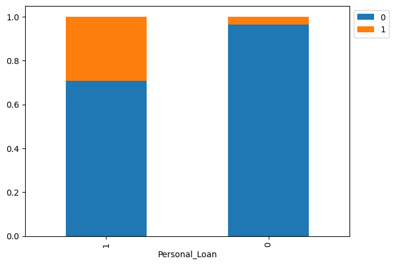

```python
stacked_barplot(data,'Personal_Loan','CD_Account') ## Complete the code to plot stacked barplot for Personal Loan and CD_Account
```

### Observation Personal_Loan Vs CD_Account

In the provided stacked bar plot, which contrasts the ownership of a CD (Certificate of Deposit) Account ('1' for yes, '0' for no) against the status of taking a personal loan ('1' for loan taken, '0' for no loan), here are the observations:

CD Account Owners Among Loan Takers: A noticeable proportion of customers who have taken a personal loan ('1') also have a CD account. This segment is represented by the orange portion on top of the left bar, which appears to be a significant fraction of that bar.

CD Account Owners Among Non-Loan Takers: Among customers who have not taken a personal loan ('0'), the proportion with a CD account is visibly smaller, as seen in the small orange segment at the top of the right bar.

Comparison Between Groups: The comparison between the two bars suggests that having a CD account may correlate with a higher likelihood of taking a personal loan. The left bar indicates a higher proportion of CD account holders among those who have taken a loan compared to those who have not.

Dominance of Non-CD Account Holders: Despite the above observation, the majority of customers, whether they have taken a personal loan or not, do not hold a CD account, as indicated by the larger blue sections of both bars.

Potential Implications: The presence of a CD account might indicate a customer’s financial stability or savings behavior, which could make them more eligible or inclined to take out a personal loan.

Marketing Strategy: For the bank, this might suggest an opportunity to target customers with CD accounts for personal loan offers, given that this group seems to be more receptive to taking loans.

Statistical Analysis Requirement: While the visualization provides a good overview, statistical testing (e.g., Chi-squared test for independence) would be necessary to confirm the strength and significance of the relationship between CD account ownership and personal loan uptake.

The visual suggests that customers with CD accounts might be a key demographic for personal loan products, and bank marketers may consider them as a potential target group in their campaigns.

#### Personal_Loan vs Online

```
Online            0     1   All
Personal_Loan
All            2016  2984  5000
0              1827  2693  4520
1               189   291   480
------------------------------------------------------------------------------------------------------------------------
```

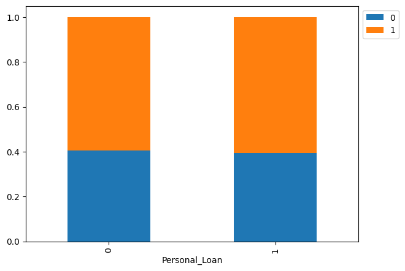

```python
stacked_barplot(data,'Personal_Loan','Online') ## Complete the code to plot stacked barplot for Personal Loan and Online
```

#### Personal_Loan vs CreditCard

```
CreditCard        0     1   All
Personal_Loan
All            3530  1470  5000
0              3193  1327  4520
1               337   143   480
------------------------------------------------------------------------------------------------------------------------
```

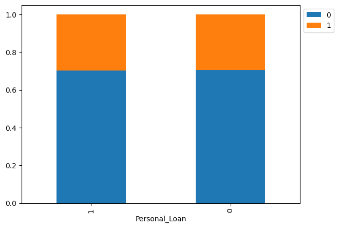

```python
stacked_barplot(data,'Personal_Loan','CreditCard') ## Complete the code to plot stacked barplot for Personal Loan and CreditCard
```

### Observations of the plot ZIPCode

Variability in Loan Uptake: There is noticeable variability in the proportion of customers with personal loans across different ZIP codes. Some ZIP codes have a higher proportion of customers who have taken out loans compared to others.

Loan Concentration: There are a few ZIP codes with particularly high proportions of loan uptake (as indicated by the height of the bars). This might suggest areas with potentially higher wealth or areas where the bank's marketing efforts have been more effective.

ZIP Code Popularity: Without knowing the total number of customers in each ZIP code, the proportions alone don't tell us about the popularity or customer density in these areas. A high proportion in a ZIP code with few customers might not be as impactful as a slightly lower proportion in a ZIP code with many customers.

Geographical Targeting for Loans: This information can be valuable for geographical targeting. The bank could focus its marketing efforts on ZIP codes with a higher propensity for taking out loans, potentially optimizing the allocation of marketing resources.

Demographic and Regional Factors: Differences in proportions may be due to demographic or regional economic factors that influence the likelihood of taking a personal loan. These factors could include average income levels, employment rates, or housing prices in those ZIP codes.

Color Coding: The color coding doesn't seem to follow a specific pattern (like gradient or categorical distinctions), which could be refined to improve the interpretability of the chart.

Overall, the chart provides a clear indication that personal loan uptake is not uniform across ZIP codes, and there are specific areas where the bank's product is more or less popular. For strategic planning, the bank might investigate what makes these ZIP codes stand out and whether these patterns hold when controlling for other variables.

#### Let's check how a customer's interest in purchasing a loan varies with their age

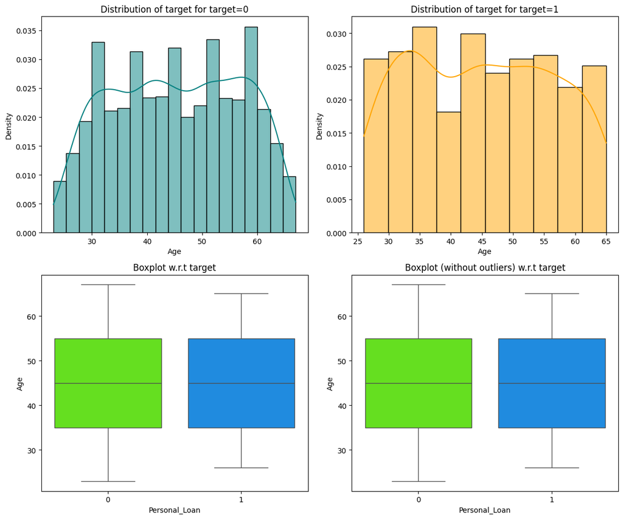

```python
distribution_plot_wrt_target(data, "Age", "Personal_Loan")
```

### Observations Age and Personal Loan

The visualizations provided seem to show the relationship between Age and Personal Loan status rather than ZipCode. Assuming the data is indeed for Age, here are the observations based on the histograms and boxplots:

Histograms of Age:

For target=0 (customers who did not take a personal loan), the histogram shows that the age distribution is fairly even, with a slight increase in density around the middle age range. For target=1 (customers who took a personal loan), the histogram suggests a similar age distribution, but perhaps with a slight concentration in the middle to upper age ranges. Kernel Density Estimate (KDE):

Both boxplots for target=0 and target=1 show a similar median age, around the mid-40s. The interquartile ranges are also similar for both groups, which indicates a similar spread of ages among those who did and did not take personal loans. Outliers:

There are no visible outliers in the boxplots, suggesting a consistent distribution of age among the bank's customers without extreme values. Implications for Personal Loans:

Age does not appear to be a distinguishing factor between those who take out personal loans and those who do not, as the distributions and central tendencies are similar across both categories. Data Analysis Considerations:

The similar distributions of age in relation to personal loan status might imply that age, in isolation, is not a significant predictor for taking out a personal loan. It would be interesting to investigate whether age interacts with other factors, such as income or education level, to influence the likelihood of taking a personal loan. If the data is indeed for ZipCode as mentioned, then the provided visualizations would not be applicable. However, if the intention was to examine Age, then the observations above would stand. It’s important to verify the correct variable being analyzed for accurate insights.

#### Personal Loan vs **Experience**

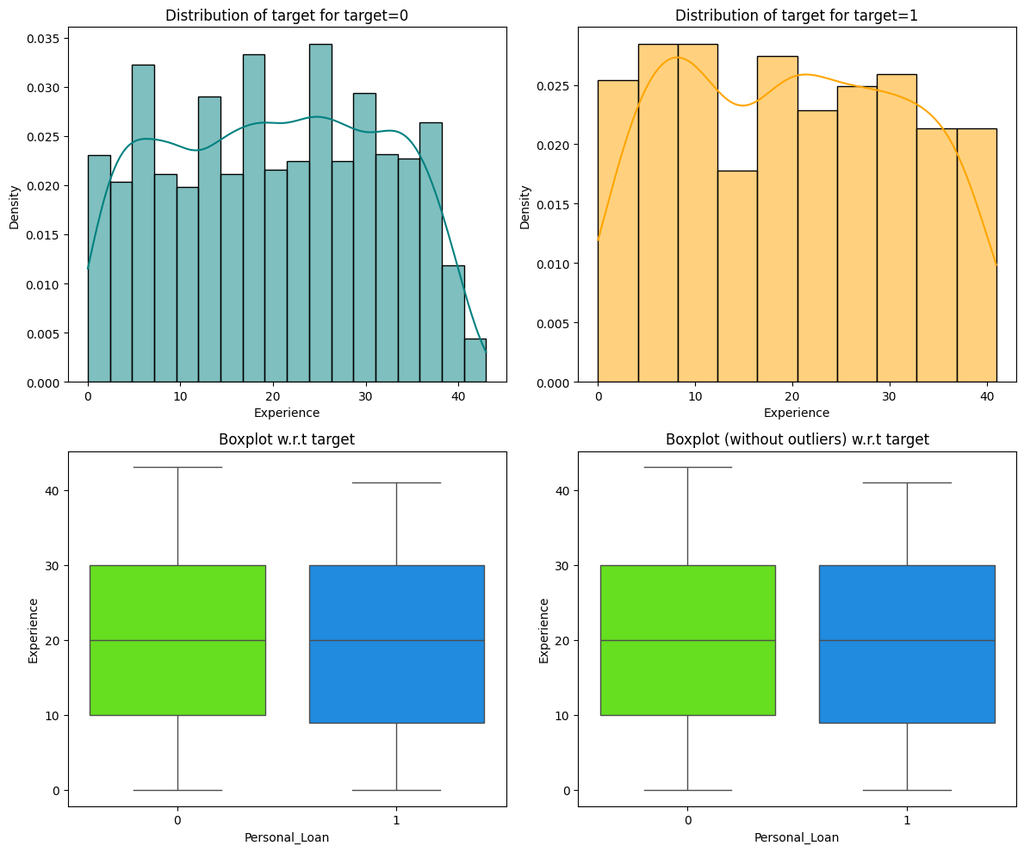

```python
distribution_plot_wrt_target(data,'Experience','Personal_Loan') ## Complete the code to plot stacked barplot for Personal Loan and Experience
```

### Observations of Personal Loan Vs Experience

The provided visualizations are histograms and boxplots of the Experience variable, split by the Personal_Loan target variable. Here are the observations based on the plots:

Histograms of Experience:

For target=0 (customers who did not take a personal loan), the histogram shows a relatively even distribution of experience across different levels with slight variations in frequency. For target=1 (customers who took a personal loan), the experience levels are again evenly distributed. There doesn't appear to be a significant difference in the shape of the distribution compared to the target=0 group. Kernel Density Estimate (KDE):

Both boxplots for target=0 and target=1 show a similar median, which lies around the 20-year mark, and similar interquartile ranges. This indicates that there is no significant difference in the years of experience between those who took a personal loan and those who did not. Outliers:

There are no visible outliers in the boxplots for either group, suggesting that extreme values of experience are not common among the customers, or they have been excluded in the "without outliers" visualization. Implications for Personal Loans:

Experience does not appear to be a differentiating factor between customers who take personal loans and those who don't, at least not in any visually obvious way. The distributions are quite similar across both categories. These insights indicate that professional experience, as measured in years, might not be a strong predictor for the likelihood of taking a personal loan. It suggests that customers of all experience levels are approximately equally likely to take out a personal loan, or at least that experience alone does not significantly influence this decision.

#### Personal Loan vs Income

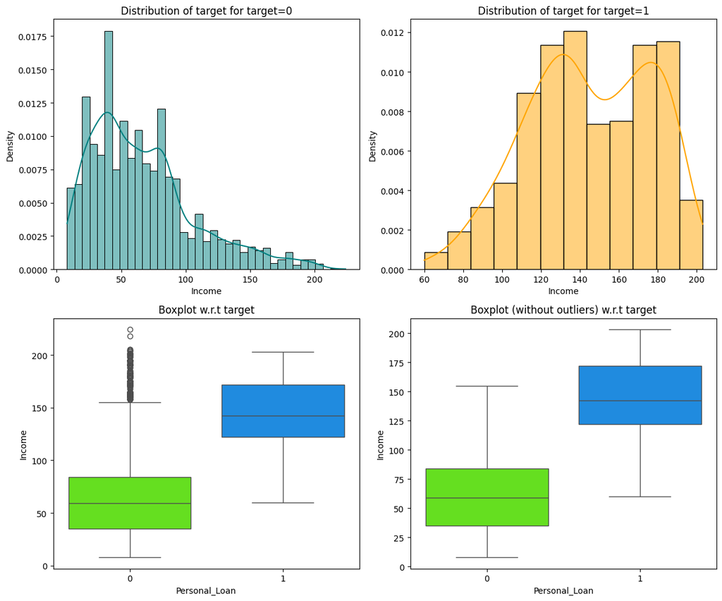

```python
distribution_plot_wrt_target(data,'Income','Personal_Loan') ## Complete the code to plot stacked barplot for Personal Loan and Income
```

### Observations Personal Loan Vs Income

In the provided visualizations comparing Income with the Personal_Loan target variable, here's what we can observe:

Histograms for Different Targets:

The KDE curves follow the histogram bars, and for target=1, the curve is higher across the range of higher incomes. This suggests that customers with higher incomes are more represented in the personal loan takers group. Boxplots for Income Relative to Personal Loan:

In the target=0 group, there are many outliers on the higher end, showing that even among those who did not take a personal loan, there are individuals with high incomes. The outliers in the target=1 group are less prominent, which might be due to scaling or a genuinely lesser variation in high incomes within this group. Income Distribution and Personal Loan Acceptance:

The comparison suggests that individuals who take personal loans tend to have higher incomes. The reason could be twofold: higher-income individuals might have higher financial needs or ambitions that a loan could help fulfill, or they might be considered more creditworthy by the bank. Analysis Implications:

For the bank, these insights can help in targeting potential customers for personal loans based on income levels. It could be inferred that marketing efforts might be more successful if focused on the higher income bracket. It's important to note that while there seems to be an association between income levels and the uptake of personal loans, further analysis would be required to understand the underlying causes and to build a predictive model if that's the goal. These visualizations serve as an excellent preliminary step in identifying possible factors related to personal loan acceptance.

#### Personal Loan vs CCAvg

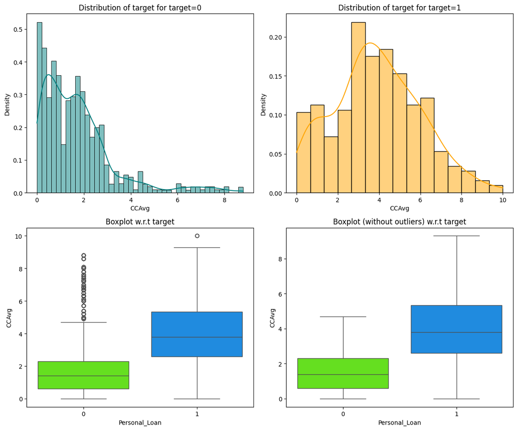

```python
distribution_plot_wrt_target(data,'CCAvg','Personal_Loan') ## Complete the code to plot stacked barplot for Personal Loan and CCAvg
```

### Observations Personal Loan Vs CCAvg

The image appears to show both histograms and boxplots for the CCAvg variable, split by the target variable Personal_Loan. Here's what we can observe:

Histograms by Target Variable:

The KDE lines on the histograms give us a smooth estimate of the distribution. Both distributions tail off as CCAvg increases, but the tail for target=1 seems to decline more slowly, reaffirming that higher credit card spending is more common in this group. Boxplots:

## Data Preprocessing (contd.)

### Outlier Detection

```python
Q1 = data.quantile(0.25)  # To find the 25th percentile and 75th percentile.
Q3 = data.quantile(0.75)

IQR = Q3 - Q1  # Inter Quantile Range (75th perentile - 25th percentile)

lower = (
    Q1 - 1.5 * IQR
)  # Finding lower and upper bounds for all values. All values outside these bounds are outliers
upper = Q3 + 1.5 * IQR
```

```python
(
    (data.select_dtypes(include=["float64", "int64"]) < lower)
    | (data.select_dtypes(include=["float64", "int64"]) > upper)
).sum() / len(data) * 100
```

```
ID                     0.00
Age                    0.00
Experience             0.00
Income                 1.92
ZIPCode                0.00
Family                 0.00
CCAvg                  6.48
Education              0.00
Mortgage               5.82
Personal_Loan          9.60
Securities_Account    10.44
CD_Account             6.04
Online                 0.00
CreditCard             0.00
dtype: float64
```

### Data Preparation for Modeling

```python
# dropping Experience as it is perfectly correlated with Age
X = data.drop(["Personal_Loan", "Experience"], axis=1)
Y = data["Personal_Loan"]

X = pd.get_dummies(X, columns=["ZIPCode", "Education"], drop_first=True)

# Splitting data in train and test sets
X_train, X_test, y_train, y_test = train_test_split(
    X, Y, test_size=0.30, random_state=1
)
```

```python
print("Shape of Training set : ", X_train.shape)
print("Shape of test set : ", X_test.shape)
print("Percentage of classes in training set:")
print(y_train.value_counts(normalize=True))
print("Percentage of classes in test set:")
print(y_test.value_counts(normalize=True))
```

```
Shape of Training set :  (3500, 478)
Shape of test set :  (1500, 478)
Percentage of classes in training set:
Personal_Loan
0    0.905429
1    0.094571
Name: proportion, dtype: float64
Percentage of classes in test set:
Personal_Loan
0    0.900667
1    0.099333
Name: proportion, dtype: float64
```

## Model Building

### Model Evaluation Criterion

### Model Building

First, let's create functions to calculate different metrics and confusion matrix so that we don't have to use the same code repeatedly for each model.

- The model_performance_classification_sklearn function will be used to check the model performance of models.
- The confusion_matrix_sklearnfunction will be used to plot confusion matrix.

```python
# defining a function to compute different metrics to check performance of a classification model built using sklearn
def model_performance_classification_sklearn(model, predictors, target):
    """
    Function to compute different metrics to check classification model performance

    model: classifier
    predictors: independent variables
    target: dependent variable
    """

    # predicting using the independent variables
    pred = model.predict(predictors)

    acc = accuracy_score(target, pred)  # to compute Accuracy
    recall = recall_score(target, pred)  # to compute Recall
    precision = precision_score(target, pred)  # to compute Precision
    f1 = f1_score(target, pred)  # to compute F1-score

    # creating a dataframe of metrics
    df_perf = pd.DataFrame(
        {"Accuracy": acc, "Recall": recall, "Precision": precision, "F1": f1,},
        index=[0],
    )

    return df_perf
```

```python
def confusion_matrix_sklearn(model, predictors, target):
    """
    To plot the confusion_matrix with percentages

    model: classifier
    predictors: independent variables
    target: dependent variable
    """
    y_pred = model.predict(predictors)
    cm = confusion_matrix(target, y_pred)
    labels = np.asarray(
        [
            ["{0:0.0f}".format(item) + "\n{0:.2%}".format(item / cm.flatten().sum())]
            for item in cm.flatten()
        ]
    ).reshape(2, 2)

    plt.figure(figsize=(6, 4))
    sns.heatmap(cm, annot=labels, fmt="")
    plt.ylabel("True label")
    plt.xlabel("Predicted label")
```

#### Build Decision Tree Model

```python
model = DecisionTreeClassifier(criterion="gini", random_state=1)
model.fit(X_train, y_train)
```

```
DecisionTreeClassifier(random_state=1)
```

#### Checking model performance on training data

```python
confusion_matrix_sklearn(model, X_train, y_train)
```

[output not shown]

```python
decision_tree_perf_train = model_performance_classification_sklearn(
    model, X_train, y_train
)
decision_tree_perf_train
```

|  | Accuracy | Recall | Precision | F1 |
| --- | --- | --- | --- | --- |
| 0 | 1.0 | 1.0 | 1.0 | 1.0 |

#### Visualizing the Decision Tree

```python
feature_names = list(X_train.columns)
print(feature_names)
```

```
['ID', 'Age', 'Income', 'Family', 'CCAvg', 'Mortgage', 'Securities_Account', 'CD_Account', 'Online', 'CreditCard', 'ZIPCode_90007', 'ZIPCode_90009', 'ZIPCode_90011', 'ZIPCode_90016', 'ZIPCode_90018', 'ZIPCode_90019', 'ZIPCode_90024', 'ZIPCode_90025', 'ZIPCode_90027', 'ZIPCode_90028', 'ZIPCode_90029'…
```

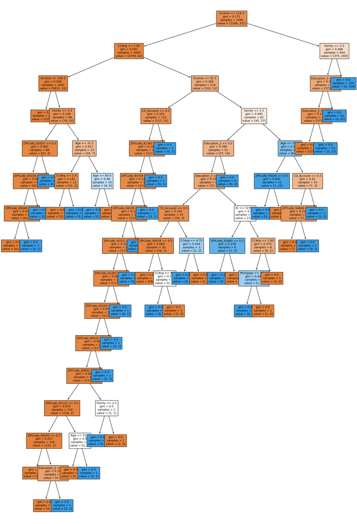

```python
plt.figure(figsize=(20, 30))
out = tree.plot_tree(
    model,
    feature_names=feature_names,
    filled=True,
    fontsize=9,
    node_ids=False,
    class_names=None,
)
# below code will add arrows to the decision tree split if they are missing
for o in out:
    arrow = o.arrow_patch
    if arrow is not None:
        arrow.set_edgecolor("black")
        arrow.set_linewidth(1)
plt.show()
```

```python
# Text report showing the rules of a decision tree -

print(tree.export_text(model, feature_names=feature_names, show_weights=True))
```

```
|--- Income <= 116.50
|   |--- CCAvg <= 2.95
|   |   |--- Income <= 106.50
|   |   |   |--- weights: [2553.00, 0.00] class: 0
|   |   |--- Income >  106.50
|   |   |   |--- Family <= 3.50
|   |   |   |   |--- ZIPCode_92007 <= 0.50
|   |   |   |   |   |--- ZIPCode_93106 <= 0.50
|   |   |   |   |   |   |--- ZIPCode_90049 <= 0.50
|   |   |   |   |   |   |   |--- weights: [63.00, 0.00] class: 0
|   |   |   |   |   |   |--- ZIPCode_90049 >  0.50
|   |   |   |   |   |   |   |--- weights: [0.00, 1.00] class: 1
|   |   |   |   |   |--- ZIPCode_93106 >  0.50
|   |   |   |   |   |   |--- weights: [0.00, 1.00] class: 1
|   |   |   |   |--- ZIPCode_92007 >  0.50
|   |   |   |   |   |--- weights: [0.00, 1.00] class: 1
|   |   |   |--- Family >  3.50
|   |   |   |   |--- Age <= 32.50
|   |   |   |   |   |--- CCAvg <= 2.40
|   |   |   |   |   |   |--- weights: [12.00, 0.00] class: 0
|   |   |   |   |   |--- CCAvg >  2.40
|   |   |   |   |   |   |--- weights: [0.00, 1.00] class: 1
|   |   |   |   |--- Age >  32.50
|   |   |   |   |   |--- Age <= 60.00
|   |   |   |   |   |   |--- weights: [0.00, 6.00] class: 1
|   |   |   |   |   |--- Age >  60.00
|   |   |   |   |   |   |--- weights: [4.00, 0.00] class: 0
|   |--- CCAvg >  2.95
|   |   |--- Income <= 92.50
|   |   |   |--- CD_Account <= 0.50
|   |   |   |   |--- ZIPCode_91360 <= 0.50
|   |   |   |   |   |--- ZIPCode_94709 <= 0.50
|   |   |   |   |   |   |--- ZIPCode_94105 <= 0.50
|   |   |   |   |   |   |   |--- ZIPCode_92521 <= 0.50
|   |   |   |   |   |   |   |   |--- ZIPCode_91203 <= 0.50
|   |   |   |   |   |   |   |   |   |--- ZIPCode_92220 <= 0.50
|   |   |   |   |   |   |   |   |   |   |--- ZIPCode_94122 <= 0.50
|   |   |   |   |   |   |   |   |   |   |   |--- truncated branch of depth 5
|   |   |   |   |   |   |   |   |   |   |--- ZIPCode_94122 >  0.50
|   |   |   |   |   |   |   |   |   |   |   |--- weights: [0.00, 1.00] class: 1
```

[output cut: 57 more lines]

```
|   |   |   |   |   |   |--- ZIPCode_94606 >  0.50
|   |   |   |   |   |   |   |--- weights: [0.00, 1.00] class: 1
|   |   |   |   |   |--- CD_Account >  0.50
|   |   |   |   |   |   |--- weights: [0.00, 2.00] class: 1
|--- Income >  116.50
|   |--- Family <= 2.50
|   |   |--- Education_3 <= 0.50
|   |   |   |--- Education_2 <= 0.50
|   |   |   |   |--- weights: [375.00, 0.00] class: 0
|   |   |   |--- Education_2 >  0.50
|   |   |   |   |--- weights: [0.00, 53.00] class: 1
|   |   |--- Education_3 >  0.50
|   |   |   |--- weights: [0.00, 62.00] class: 1
|   |--- Family >  2.50
|   |   |--- weights: [0.00, 154.00] class: 1
```

```python
# importance of features in the tree building ( The importance of a feature is computed as the
# (normalized) total reduction of the criterion brought by that feature. It is also known as the Gini importance )

print(
    pd.DataFrame(
        model.feature_importances_, columns=["Imp"], index=X_train.columns
    ).sort_values(by="Imp", ascending=False)
)
```

```
                    Imp
Income         0.297816
Family         0.248530
Education_2    0.165238
Education_3    0.144207
CCAvg          0.047550
...                 ...
ZIPCode_92110  0.000000
ZIPCode_92109  0.000000
ZIPCode_92106  0.000000
ZIPCode_92104  0.000000
ZIPCode_93009  0.000000

[478 rows x 1 columns]
```

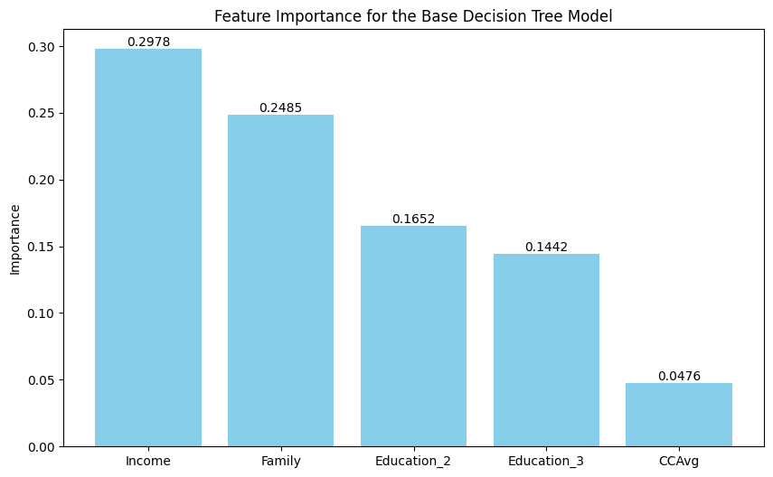

```python
import matplotlib.pyplot as plt

# Data for feature importance
features = ['Income', 'Family', 'Education_2', 'Education_3', 'CCAvg']
importance = [0.297816, 0.248530, 0.165238, 0.144207, 0.047550]

# Create bar graph
plt.figure(figsize=(10, 6))
bars = plt.bar(features, importance, color='skyblue')
plt.ylabel('Importance')
plt.title('Feature Importance for the Base Decision Tree Model')

# Add the importance values on top of the bars
for bar in bars:
    yval = bar.get_height()
    plt.text(bar.get_x() + bar.get_width()/2, yval, round(yval, 4), ha='center', va='bottom')

# Show the plot
plt.show()
```

[figure not shown]

```python
importances = model.feature_importances_
indices = np.argsort(importances)

plt.figure(figsize=(8, 8))
plt.title("Feature Importances")
plt.barh(range(len(indices)), importances[indices], color="violet", align="center")
plt.yticks(range(len(indices)), [feature_names[i] for i in indices])
plt.xlabel("Relative Importance")
plt.show()
```

#### Checking model performance on test data

```python
confusion_matrix_sklearn(model, X_test, y_test) ## Complete the code to create confusion matrix for test data
```

[output not shown]

```python
decision_tree_perf_test = model_performance_classification_sklearn(model, X_test, y_test) ## Complete the code to check performance on test data
decision_tree_perf_test
```

|  | Accuracy | Recall | Precision | F1 |
| --- | --- | --- | --- | --- |
| 0 | 0.981333 | 0.872483 | 0.935252 | 0.902778 |

```python
# Create a DataFrame for the training metrics
train_metrics = pd.DataFrame({
    "Accuracy": [1.0],
    "Recall": [1.0],
    "Precision": [1.0],
    "F1": [1.0]
}, index=["Train"])

# Create a DataFrame for the testing metrics
test_metrics = pd.DataFrame({
    "Accuracy": [0.981333],
    "Recall": [0.872483],
    "Precision": [0.935252],
    "F1": [0.902778]
}, index=["Test"])

# Concatenate both DataFrames for comparison
comparison_table = pd.concat([train_metrics, test_metrics])

# Display the comparison table
print(comparison_table)
```

```
       Accuracy    Recall  Precision        F1
Train  1.000000  1.000000   1.000000  1.000000
Test   0.981333  0.872483   0.935252  0.902778
```

## Model Performance Improvement

#### Pre-Pruning

```python
# Choose the type of classifier.
estimator = DecisionTreeClassifier(random_state=1)

# Grid of parameters to choose from
parameters = {
    "max_depth": np.arange(6, 15),
    "min_samples_leaf": [1, 2, 5, 7, 10],
    "max_leaf_nodes": [2, 3, 5, 10],
}

# Type of scoring used to compare parameter combinations
acc_scorer = make_scorer(recall_score)

# Run the grid search
grid_obj = GridSearchCV(estimator, parameters, scoring=acc_scorer, cv=5)
grid_obj = grid_obj.fit(X_train, y_train)

# Set the clf to the best combination of parameters
estimator = grid_obj.best_estimator_

# Fit the best algorithm to the data.
estimator.fit(X_train, y_train) ## Complete the code to fit model on train data
```

```
DecisionTreeClassifier(max_depth=6, max_leaf_nodes=10, min_samples_leaf=10,
                       random_state=1)
```

**Checking performance on training data**

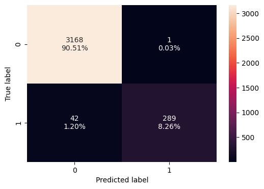

```python
confusion_matrix_sklearn(estimator, X_train, y_train) ## Complete the code to create confusion matrix for train data
```

```python
decision_tree_tune_perf_train = model_performance_classification_sklearn(estimator, X_train, y_train) ## Complete the code to check performance on train data
decision_tree_tune_perf_train
```

|  | Accuracy | Recall | Precision | F1 |
| --- | --- | --- | --- | --- |
| 0 | 0.987714 | 0.873112 | 0.996552 | 0.930757 |

**Visualizing the Decision Tree**

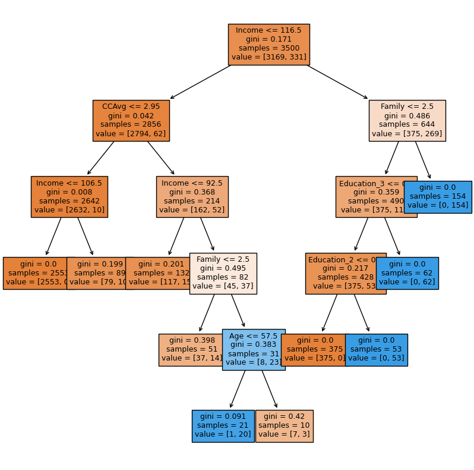

```python
plt.figure(figsize=(10, 10))
out = tree.plot_tree(
    estimator,
    feature_names=feature_names,
    filled=True,
    fontsize=9,
    node_ids=False,
    class_names=None,
)
# below code will add arrows to the decision tree split if they are missing
for o in out:
    arrow = o.arrow_patch
    if arrow is not None:
        arrow.set_edgecolor("black")
        arrow.set_linewidth(1)
plt.show()
```

```python
# Text report showing the rules of a decision tree -

print(tree.export_text(estimator, feature_names=feature_names, show_weights=True))
```

```
|--- Income <= 116.50
|   |--- CCAvg <= 2.95
|   |   |--- Income <= 106.50
|   |   |   |--- weights: [2553.00, 0.00] class: 0
|   |   |--- Income >  106.50
|   |   |   |--- weights: [79.00, 10.00] class: 0
|   |--- CCAvg >  2.95
|   |   |--- Income <= 92.50
|   |   |   |--- weights: [117.00, 15.00] class: 0
|   |   |--- Income >  92.50
|   |   |   |--- Family <= 2.50
|   |   |   |   |--- weights: [37.00, 14.00] class: 0
|   |   |   |--- Family >  2.50
|   |   |   |   |--- Age <= 57.50
|   |   |   |   |   |--- weights: [1.00, 20.00] class: 1
|   |   |   |   |--- Age >  57.50
|   |   |   |   |   |--- weights: [7.00, 3.00] class: 0
|--- Income >  116.50
|   |--- Family <= 2.50
|   |   |--- Education_3 <= 0.50
|   |   |   |--- Education_2 <= 0.50
|   |   |   |   |--- weights: [375.00, 0.00] class: 0
|   |   |   |--- Education_2 >  0.50
|   |   |   |   |--- weights: [0.00, 53.00] class: 1
|   |   |--- Education_3 >  0.50
|   |   |   |--- weights: [0.00, 62.00] class: 1
|   |--- Family >  2.50
|   |   |--- weights: [0.00, 154.00] class: 1
```